# ZEAL population analysis: proposed scope, phenotypes, and current QTL status

Planning document for group discussion. The proposed structure follows Chen et al. 2019 (TeoNAM) as a template only.

Author

Fausto Rodríguez-Zapata

Published

August 10, 2026

## Purpose

This document is to align the group on the analysis scope for the ZEAL (Zea Exotic Allele Library) population before we commit to writing. It collects three things: a proposed paper structure, the phenotype inventory with current QTL counts, and a first draft of the whole-genome QTL figure. The structure borrows the shape of Chen et al. 2019 (TeoNAM), which is the closest published analog.

The phenotype panel is fixed to the measurements we already have. This document does not propose scoring any new phenotypes.

## Proposed paper structure (for discussion)

Resource-first framing, with hypothesis-driven vignettes on the traits where the teosinte contrast is sharpest. Proposed, not settled:

1. **Introduction.** Teosinte as a reservoir of domestication and adaptation alleles; what an exotic-allele library in a maize background offers; how ZEAL relates to and differs from TeoNAM.
2. **Materials and methods.** Population and design; SNP50K plus skim genotyping and the RTIGER ancestry mosaic (cite the nilHMM methods paper, do not re-derive it); phenotyping across CLY23, CLY25, and Guadalajara; SpATS BLUEs and empirical-logit binary traits; R/qtl joint scan and MLM SNP50K.
3. **Results.**
   - The resource: population, marker density, ancestry-mosaic summary.
   - Phenotypic variation: heritabilities and trait correlations across environments.
   - Genetic architecture: the whole-genome QTL figure (below).
   - Comparison with TeoNAM: the four overlapping traits (table below).
   - Hypothesis-driven vignettes: flowering time (with the North Carolina vs Guadalajara photoperiod contrast) and the ZEAL-signature qualitative traits TeoNAM never scored (StPu, StPi, Kinki, inv4m).
4. **Discussion.** Resource value; what the overlap does and does not cover; novel loci.
5. **Data and resource availability.** Genotype and phenotype data, tracked reproduction scripts, and the zealbrowser fragment browser.

## Phenotypes we have

Fourteen mapped traits. QTL counts are computed live from the R/qtl joint scan with a taxon covariate (taxa Zv, Zx, Zl, Zd, Zh). Peaks are called with the R/qtl2 peakdrop rule (peakdrop = 5), Broman’s algorithm ported to our bcsft scan, which splits a chromosome into separate peaks only where the LOD valley between them drops at least 5 below both. This is the authoritative peak set for reported QTL. Counts are provisional, not final.

| Trait | Description | Field | Type | QTL (joint scan) | Status |
| --- | --- | --- | --- | --- | --- |
| DTA | days to anthesis | CLY23 + CLY25 | SpATS BLUE | 2 | TeoNAM overlap |
| DTS | days to silk | CLY23 + CLY25 | SpATS BLUE | 2 | TeoNAM overlap |
| PH | plant height | CLY23 + CLY25 | SpATS BLUE | 5 | TeoNAM overlap |
| Prolif | prolificacy (ears per plant) | CLY23 + CLY25 | SpATS BLUE | 4 | TeoNAM overlap |
| EH | ear height | CLY23 + CLY25 | SpATS BLUE | 4 | mapped; not a TeoNAM trait |
| EN | ear number | CLY23 + CLY25 | SpATS BLUE | 10 | mapped; not a TeoNAM trait |
| LAE | leaves above ear | CLY25 | SpATS BLUE | 3 | mapped; single environment |
| NBR | brace root number | CLY23 + CLY25 | SpATS BLUE | 1 | mapped; not a TeoNAM trait |
| SPAD | leaf greenness (leaf N proxy) | CLY25 | SpATS BLUE | 3 | source to standardize |
| SPAD20DAS | SPAD 20 days after sowing | introfinder | as measured (per line mean) | 0 | secondary source (introfinder) |
| SPAD36DAS | SPAD 36 days after sowing | introfinder | as measured (per line mean) | 2 | secondary source (introfinder) |
| StPi | stem pigment, anthocyanin (binary) | CLY23 | empirical logit | 5 | qualitative; ZEAL signature |
| StPu | stem pubescence, macrohairs (binary) | CLY23 | empirical logit | 0 | qualitative; 0 QTL in taxon scan |
| Kinki | zigzag culm (binary) | CLY23 | empirical logit | 3 | qualitative; single environment |

**EN vs Prolif.** These are distinct ear-count traits (definitions in TERMINOLOGY.md): EN (ear number) counts the number of nodes that bear ears, whereas Prolif (prolificacy) counts the total number of ears per plant, so a single node bearing more than one ear adds to Prolif but not to EN. The CLY25 protocol counts every ear where a cob can be felt.

**Notes on the current numbers.**

- **StPu shows 0 QTL in the taxon-covariate joint scan but has peaks in the per-taxon scans.** This looks like the taxon covariate absorbing the signal, and it needs understanding before StPu is reported. SPAD20DAS shows the same pattern (0).
- **peakdrop = 5 is the principled middle** between R/qtl refine (over-segments; EN gave 17) and one peak per chromosome (too coarse). At peakdrop = 5 the four overlap traits are unchanged, while EN gives 10 and StPi gives 5. The knob was compared over 1.5, 3, 5, and Inf in `scripts/detect_peaks_peakdrop.R` before settling on 5.
- **The taxon-covariate joint scan is authoritative** for the reported QTL, matching the family-nested joint scan TeoNAM used, here nested on the five teosinte taxa.

## Decisions still open

These are existing data or provenance cleanups, not new phenotyping.

[output not shown]

## Overlap with TeoNAM (Chen et al. 2019)

TeoNAM measured 22 traits: 15 domestication traits (CULM, EB, ED, EL, GLCO, GLUM, KRN, KW, LFLN, LFWD, PROL, REPE, SHN, STAM, TILN) and 7 agronomic traits (ASI, BARE, DTA, DTS, PLHT, TBN, YEPE). Of these, four are measured in ZEAL:

| ZEAL | Chen 2019 | Trait | Chen’s bucket |
| --- | --- | --- | --- |
| DTA | DTA | days to anthesis | agronomic |
| DTS | DTS | days to silk | agronomic |
| PH | PLHT | plant height | agronomic |
| Prolif | PROL | prolificacy | domestication (Chen scored binary presence; ZEAL scores a count) |

Read honestly: three of the four overlaps are Chen’s agronomic traits and one (prolificacy) is his domestication bucket. So the comparison reads as “ZEAL recovers TeoNAM’s agronomic architecture plus one domestication trait.” The classic domestication-syndrome traits that carry TeoNAM’s headline results (shattering, glume/cupule, kernel row number, tillering) are not in the ZEAL panel, so the ZEAL contribution on the domestication side runs through the qualitative traits TeoNAM did not score (StPu, StPi, Kinki, inv4m).

## Current QTL status: draft figure

Draft, scoped to the four TeoNAM-overlap traits (the same four as the comparison table above). Taxon-covariate joint scan; peaks and 1.5-LOD support intervals from the R/qtl2 peakdrop rule (peakdrop = 5) ported to our bcsft scan (`scripts/detect_peaks_peakdrop.R`). Produced by `scripts/zeal_qtl_effects.R` (per-QTL variance and effect) and `scripts/fig_zeal_qtl_summary.R` (the composite), reading the R/qtl joint-scan outputs.

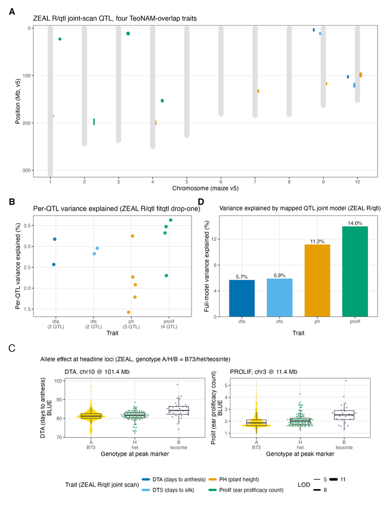

Figure 1: Draft. ZEAL R/qtl joint-scan QTL for the four TeoNAM-overlap traits (DTA, DTS, PH, Prolif). A: genome-wide QTL positions in Mb, bars are the 1.5-LOD peakdrop support intervals, bar width scaled by LOD. B: per-QTL variance explained (fitqtl drop-one). C: raw allele effect at two headline loci, phenotype BLUE by genotype class (A = B73, H = het, B = teosinte). D: variance explained by the mapped-QTL joint model.

Full-model variance explained by the mapped QTL:

| Trait | QTL | Variance explained (%) |
| --- | --- | --- |
| dta | 2 | 5.7 |
| dts | 2 | 5.9 |
| ph | 5 | 11.2 |
| prolif | 4 | 14.0 |

**Draft refinements still needed** (so the group reads the figure as provisional):

- Support intervals are now the tight 1.5-LOD peakdrop intervals, which fixes the earlier wide-bar problem. Caution: the mechanical candidate-overlap test now labels no genes, but that is a limitation of the test (and of tight intervals in this population), not evidence against the candidates. The DTA chromosome 10 peak at 101.4 Mb is very likely *ZmCCT10* (Zm00001eb418700, about 96.2 Mb), the major chromosome 10 flowering-time domestication gene; the interval simply does not reach it. Candidate labeling should use biological knowledge, not raw interval overlap.
- Panel C Prolif headline is a top-LOD peak with no candidate overlap.
- Panel reading order and gene-symbol styling to fix.

## Photoperiod: Guadalajara short-day flowering and the day-length contrast

The photoperiod-sensitivity axis of the paper. The Mexican team (Lino, Berenice) evaluated the population in **Guadalajara in 2024** (subtropical, short-day, ~20.5°N; CUCBA and La Soledad); Ruben shared the field books. Guadalajara flowering (FM = days to anthesis, FF = days to silk) is the short-day complement to our long-day Clayton data (Central Crops Research Station, ~35.7°N), and the ~15° latitude gap is the photoperiod contrast the paper hinges on.

**What we can actually use.** Of the two Guadalajara sites, only **CUCBA** carries real flowering data: the La Soledad flowering columns equal CUCBA minus a constant 3 days (per genotype, slope 1, R² = 1 for both FM and FF), so they carry no independent flowering signal and are excluded. Whether that is a literal copy or a planting-date arithmetic artifact (shared flowering dates, planting dates 3 days apart) cannot be told from these processed files — it needs the raw flowering and planting dates. CUCBA is a single **unreplicated augmented** environment (each NIL in one incomplete block; only the 3 checks replicated), and the CUCBA↔︎pedigree join currently uses the Genealogía crosswalk — so these results are **provisional** pending real La Soledad flowering (or more replication) and the definitive three-way sample sheet.

Three R/qtl notebooks, on the same TeoNAM JLM grid as the other ZEAL scans:

- CUCBA DTA — short-day additive scan: one strong QTL on **chr9 (~46 Mb, LOD 9.5)**; the teosinte allele advances short-day flowering.
- CUCBA DTS — short-day additive scan: **chr9 (~37 Mb, LOD 10.0)**.
- Photoperiod G×ME: marker × macroenvironment (short-day CUCBA vs long-day Clayton) interaction, R/qtl Approach B with a 1000-permutation line-level threshold. Significant photoperiod-sensitivity loci on **chr10 (~122 Mb)** and **chr9 (~92–94 Mb)** for *both* DTA and DTS — distinct from the additive chr9 QTL, and not at *ZmCCT10* (~96 Mb) by position, so the gene identities need a coordinate check rather than assignment by chromosome.

Still needed from the Mexican team: the **field layout** (plot coordinates) and **planting dates** per site (for spatial correction and a GDD/daylength covariate), and confirmation of whether **La Soledad flowering** was really measured. The paper’s working outline (Hannah) is [here](https://docs.google.com/document/d/1qyIBb5IQhNMdH4uSiBBthCNJrLP2cydYtHcREgFBYlw/edit) (Google Doc).

## QTL by taxon

The taxon-covariate joint scan pools the five teosinte taxa. A separate question is which taxon contributes each QTL. TeoNAM answered the analog with a heatmap of allele effect by donor; the ZEAL analog is effect by taxon (Zv, Zx, Zl, Zd, Zh). We also run per-taxon additive scans, which show in one multicolor panel where each taxon peaks. Proposed: a paper section on the per-taxon QTL, using the effect-by-taxon summary plus the per-taxon scans.

Pigmentation (StPi, stem anthocyanin) is a clean example. Different taxa peak at different anthocyanin-pathway loci:

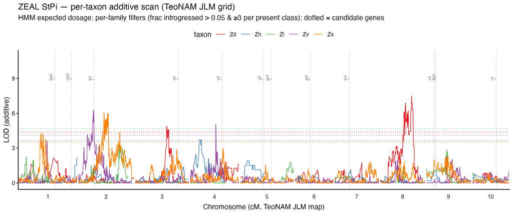

Figure 2: ZEAL StPi (stem anthocyanin) per-taxon additive scan on the TeoNAM JLM grid. LOD by taxon (Zd, Zh, Zl, Zv, Zx); dotted verticals mark anthocyanin-pathway candidate genes (b1, a1, c2, pr1, pl1, bz1, and others). Different taxa contribute pigmentation signal at different loci, for example Zx and Zv near b1 on chromosome 2 and Zd near chromosome 8.